# LDA_data analysis

Song Hyun,IM

# Why is Topic Modeling Useful?

- document summaries : Use topic models to understand and summarize scientific articles enabling faster research and development. The same applies to historical documents, newspapers, blogs, and even fiction.
- text classification : Topic modeling can improve classification by grouping similar words together in topics rather than using each word as an individual feature.
- recommendation systems : Using probabilities based on similarity, you can build recommendation systems. You could recommend articles for readers with a topic structure similar to articles they have already read.

# libraries and Functions

## libraries for data analysis

```r
library(tidytext) #text mining, unnesting
library(topicmodels) #the LDA algorithm
library(tidyr) #gather()
library(dplyr) #awesome tools
library(ggplot2) #visualization
library(kableExtra) #create attractive tables
library(knitr) #simple table generator
library(ggrepel) #text and label geoms for ggplot2
library(gridExtra)
library(formattable) #color tile and color bar in `kables`
library(tm) #text mining
library(circlize) #already loaded, but just being comprehensive
library(plotly) #interactive ggplot graphs
```

## Function for visualization

```r
# define some colors to use
my_colors<-c("#E69F00", "#56B4E9", "#009E73", "#CC79A7", "#D55E00", "#D65E00")
```

### customize ggplot2 default theme setting

```r
theme_lyrics<-function(aticks=element_blank(),
                       pgminor=element_blank(),
                       lt=element_blank(),
                       lp="none")
{
  theme(plot.title = element_text(hjust = 0.5), #center the title
        axis.ticks = aticks,#set axis ticks to on or off
        panel.grid.minor = pgminor,#turn on or off the minor grid lines
        legend.title = lt,#turn on or off the legend title
        legend.position = lp#turn on or off the legend
        )
}
```

### customize the text tables for consistency using HTML formatting

```r
my_kable_styling <- function(dat,caption){
  kable(dat,"html",escape=FALSE,caption=caption) %>%
  kable_styling(bootstrap_options = c("striped","condensed","bordered"),full_width = FALSE)
}
```

### word chart

```r
word_chart<-function(data,input,title){
  data %>%
  # set y=1 to just plot one variable and use word as the label
  ggplot(aes(as.factor(row),1,label=input,fill=factor(topic)))+
    # you want the words, not the points
    geom_point(color="transparent")+
    # rectangule underneath the text
    geom_label_repel(nudge_x = .2,
                     direction = "y",
                     box.padding = 0.1,
                     segment.color = "transparent",
                     size=3)+
    facet_grid(~topic)+
    theme_lyrics()+
    theme(axis.text.y = element_blank(),axis.title.x = element_blank(),
          #axis.title.x=element_text(size=9)),
          panel.grid = element_blank(),panel.background=element_blank(),
          panel.border=element_rect("lightgray",fill=NA),
          strip.text.x=element_text(size=9))+
    labs(x=NULL,y=NULL,title=title)+ #xlab=NULL+ylab=NULL+ggtitle(title)+
    coord_flip()
}
```

# Get Tidy Prince Dataset and Balanced Tidy Dataset of All Sources and 3 Sources

```r
three_sources_tidy_balanced <- read.csv("C:/Users/user/Dropbox/Lecture/CS/LDA_data/three_sources_tidy_balanced.csv",
                                        stringsAsFactors = FALSE)

all_sources_tidy_balanced <- read.csv("C:/Users/user/Dropbox/Lecture/CS/LDA_data/all_sources_tidy_balanced.csv",
                                      stringsAsFactors = FALSE)

prince_tidy <- read.csv("C:/Users/user/Dropbox/Lecture/CS/LDA_data/prince_tidy.csv",
                        stringsAsFactors = FALSE)
```

# Building Models with LDA

## Goal

- finding significant thematically related terms (topics) in unstructed textual data measured as patterns of word co-occurence.
- The basic components of topic models are documents / terms / topics.
- LDA is an unsupervised learning method which discovers different topics underlying collection of documents, where each document is a collection of words.

## Assumptions

1. Every document is a combination of one or more topic(s)
2. Every topic is a mixture of words

## Steps for finding groups of related words

- LDA seeks to find groups of related words. It is an iterative, generative algorithm. Here are the two main steps.
1. During initialization, each word is assigned to a random topic
2. The algorithm goes through each word iteratively and reassigns the word to a topic with the following considerations:
- the probability the word belongs to topic
- the probability the document will be generated by a topic

the concept behind the LDA topic model is that words belonging to a topic appear together in documents. It tries to model each document as a mixture of topics and each topic as a mixture of words. (You may see this referred to as a mixed-membership model.) You can then use the probability that a document belongs to a particular topic to classify it accordingly. In your case, since you know the writer of the document from the original data, you can then recommend an artist/author based on similar topic structures. Now it’s time to take a look at an example.

# Model One : LDA for Three Writers

## Examine the data

for this model, you will use the dataset with a combination of three distinct writers (i.e. sources) and look for hidden topics. In order to helpy you understand the power of topic modeling, these three chosen sources are very different and intuitively you know they cover three different topics. As a result, you’ll tell your model to create three topics and see how smart it is: First you want to examine your dataset using your “my_kable_styling()” function along with “color_bar()” and “color_tile()” from the “formmatable” package.

```r
# group the dataset by writer(source) and count the words
three_sources_tidy_balanced %>%
  group_by(source) %>%
  mutate(word_count=n()) %>%
  select(source,genre,word_count) %>%  # only need these fields
  distinct() %>% # unique
  ungroup() %>%

  ## assign color bar for word_count that varies according to size
  ## create static color for source and genre

  mutate(word_count=color_bar("lightpink")(word_count),
         source=color_tile("lightblue","lightblue")(source),
         genre=color_tile("lightgreen","lightgreen")(genre)) %>%
  my_kable_styling("Three Sources Stats")
```

Three Sources Stats

| source | genre | word_count |
| --- | --- | --- |
| icebergs | earth_science | 32616 |
| machine_learning | data_science | 32616 |
| prince | pop-rock | 32616 |

## Create the Document-Term Matrix

Since you currently have a balanced, tidy dataset with Princelyrics and two bookes, you’ll first want to create a document-term matrix(DTM) in which each document is a row, and each column is a term. This format is required for the LDA algorithm. A document refers to a song in the lyrics and a page number in the books.

First, you’ll take your tidy data and count the words in a document, then pipe that into tidytext’s “cast_dtm()” function where document is the name of field with the document name and word is the name of the field with the term. There are other parameters you could pass, but these two are required.

```r
three_sources_dtm_balanced <-three_sources_tidy_balanced %>%
  # get word count per document to pass to cast_dtm
  count(document,word,sort=TRUE) %>%
  ungroup() %>%
  # create a DTM with docs as rows and words as columns
  cast_dtm(document,word,n)

# examine the structure of the DTM
three_sources_dtm_balanced
```

```
## <<DocumentTermMatrix (documents: 1449, terms: 13608)>>
## Non-/sparse entries: 71386/19646606
## Sparsity           : 100%
## Maximal term length: 27
## Weighting          : term frequency (tf)
```

This tells you how many documents and terms you have and that this is a very sparse matrix. The word sparse implies that the DTM contains mostly empty fields. Because of the vast vocabulary of possible terms from all documents, only a few will be used in each individual document.

If you look at the contents of a few rows and columns of the DTM using the inspect() function from the tm package, you’ll see that each row is a document and each column is a term. (Feel free to use str() to see the actual structure.)

```r
# look at 4 documents and 8 words of the DTM
inspect(three_sources_dtm_balanced[1:4,1:8])
```

```
## <<DocumentTermMatrix (documents: 4, terms: 8)>>
## Non-/sparse entries: 9/23
## Sparsity           : 72%
## Maximal term length: 9
## Weighting          : term frequency (tf)
## Sample             :
##             Terms
## Docs         beautiful dance party push rock roll shake style
##   party up           0     0    40    0    1    2     0     0
##   push it up         0     1     1   56    0    0     0     0
##   shake              0     0     1    0    0    0    52     0
##   style              0     0     0    0    0    0     0    32
```

## Set Variables

Now that you know what is needed as input to build your model, set two variables that you can simply reset when constructing each model. You’ll call these source_dtm and source_tidy.

```r
# assign the source dataset to generic var names
# so we can use a generic function per model
source_dtm <- three_sources_dtm_balanced
source_tidy <- three_sources_tidy_balanced
```

## Fit the Model

Finally, you get to the fun part of fitting the model. The code is simple, but to be a good Data Scientist, you’ll want to understand what is happening behind the scenes. Although this is a cursory description, there is a wealth of information on LDA online. For your purposes, you’ll just need to know four parameters:

- 1. the input
- 2. the number of topics
- 3. the sampling method
- 4. the seed.

Since you know your dataset contains three distinct writers, you’ll set k to 3 and set seed to a constant so that you can obtain repeatable results. There are other control parameters, thus the list format in the code, but you’ll just use seed for now. The method parameter defines the sampling algorithm to use. You’ll use the GIBBS sampling method. The default is VEM, but in my experience, it does not perform as well as the alternative GIBBS sampling method.

A short technical explanation of GIBBS sampling is that it performs a random walk that starts at some point which you can initialize (you’ll just use the default of 0) and at each step moves plus or minus one with equal probability. Read a detailed description here if you are interested in the details.

```r
k <- 3 #number of topics
seed = 1234 #necessary for reproducibility
#fit the model passing the parameters discussed above
#you could have more control parameters but will just use seed here
lda <- LDA(source_dtm, k = k, method = "GIBBS", control = list(seed = seed))
#examine the class of the LDA object
class(lda)
```

```
## [1] "LDA_Gibbs"
## attr(,"package")
## [1] "topicmodels"
```

The next step is to open up that object and see what the results are. You can use the tidy() function to put it in a format that is easy to understand. Within the call to tidy() pass the LDA object and beta for the matrix argument. Passing beta provides you with the per-topic-per-word probabilities from the model. The following example, using the term iceberg, shows the probability of that word being in each topic. The word iceberg has a higher probability of being generated in Topic 1.

```r
#convert the LDA object into a tidy format
#passing "beta" shows the word probabilities
#filter on the word iceberg as an example
#results show probability of iceberg for each topic
tidy(lda, matrix = "beta") %>% filter(term == "iceberg")
```

```
## # A tibble: 3 x 3
##   topic term          beta
##   <int> <chr>        <dbl>
## 1     1 iceberg 0.000198
## 2     2 iceberg 0.00000292
## 3     3 iceberg 0.00000315
```

## Identify Themes with Top Words

To understand the model clearly, you need to see what terms are in each topic. Build a function that will tidy the LDA model, and extract the top terms for each topic. In other words, the terms per topic with the largest beta values. Inside this function, you’ll refer to word_chart() that you built earlier to generate a nice display of the three topics and the top words. Set num_words to 10 for this example, but you can play around with that number to get different perspectives on the topics.

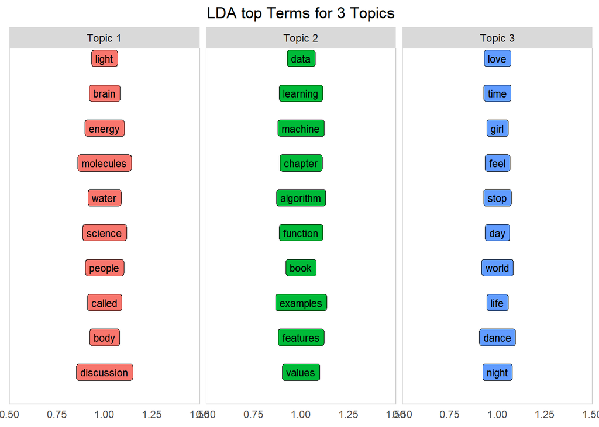

```r
num_words<-10 # the number of words to visualize

# create function that accepts the lda model and num word to display
top_terms_per_topic<-function(lda_model,num_words){

  #tidy LDA object to get word, topic, and probability (beta)
  topics_tidy<-tidy(lda_model,matrix="beta")

  top_terms<-topics_tidy %>%
    group_by(topic) %>%
    arrange(topic,desc(beta)) %>%
    # get the top num_words PER topic
    slice(seq_len(num_words)) %>%
    arrange(topic,beta) %>%
    # row is required for the word_chart() function
    mutate(row=row_number()) %>%
    ungroup() %>%
    # add the word Topic to topic labels
    mutate(topic=paste("Topic",topic,sep=" "))
    # create a title to pass to word_chart
    title<-paste("LDA top Terms for",k,"Topics")
    # call the word_cahrt function you built in prep work
    word_chart(top_terms,top_terms$term,title)
}

# call the function you just built!
top_terms_per_topic(lda,num_words)
```

Unsupervised learning always requires human interpretation…but these topics clearly reflect the three sources of Icebergs, Machine Learning, and Prince! Even though this is a very simple example, it is pretty amazing when you think about the possibilities!

## Classify Documents

In addition to estimating each topic as a mixture of words, LDA also shows each document as a mixture of topics. This time when you tidy the LDA model, use matrix = “gamma” and you’ll get the per-document-per-topic probabilities. For example, look at Prince’s song 1999. Here you see that, just as a word will be associated with multiple topics, the same is true for documents. This refers back to that mixed-membership concept. Below you can see that 1999 is most likely to appear in Topic 3.

```r
#this time use gamma to look at the prob a doc is in a topic
#just look at the Prince song 1999 as an example
tidy(lda, matrix = "gamma") %>% filter(document == "1999")
```

```
## # A tibble: 3 x 3
##   document topic gamma
##   <chr>    <int> <dbl>
## 1 1999         1 0.170
## 2 1999         2 0.170
## 3 1999         3 0.661
```

This song belongs to each topic, but at a different percentage, represented by the gamma value. Some documents fit in some topics better than others. As shown above, 1999 has a higher gamma value for Topic 3.

## Chord Diagram

In order to clarify your understanding of what LDA does, take a look at this circle plot. This plot shows what percentage of docs from each source belongs to each topic. In order to create it, join the tidy LDA model back to source_tidy where you stored the actual source (i.e. the writer), and join by document. Then if you do the proper grouping, you can get the average gamma value per source, per topic. Now you can see, for each source, into which topic the majority of documents fall.

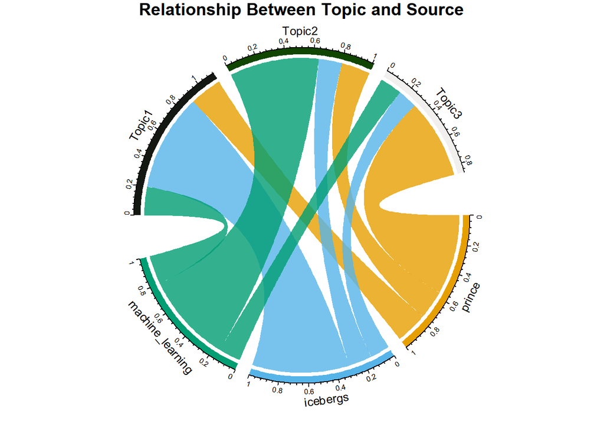

```r
#using tidy with gamma gets document probabilities into topic
#but you only have document, topic and gamma

source_topic_relationship <-tidy(lda,matrix="gamma") %>%
  # join to original tidy data by doc to get the source field
  inner_join(three_sources_tidy_balanced,by="document") %>%
  select(source,topic,gamma) %>%
  group_by(source,topic) %>%
  #get the average doc gamma value per source/topic
  mutate(mean=mean(gamma)) %>%
  #remove the gamma value as you only need the mean
  select(-gamma) %>%
  #removing gamma created duplicates so remove them
  distinct()

#relabel topics to include the word Topic
source_topic_relationship$topic=paste("Topic",source_topic_relationship$topic,sep="")

circos.clear() # Reset the circular layout parameters
#assign colors to the outside bars around the circle
grid.col=c("prince"=my_colors[1],
           "icebergs" = my_colors[2],
             "machine_learning" = my_colors[3],
             "Topic 1" = "grey", "Topic 2" = "grey", "Topic 3" = "grey")

# set the global parameters for the circular layout. Specifically the gap size(15)
#this also determines that topic goes on top half and source on bottom half
circos.par(gap.after = c(rep(5, length(unique(source_topic_relationship[[1]])) - 1), 15,
                         rep(5, length(unique(source_topic_relationship[[2]])) - 1), 15))

#main function that draws the diagram. transparancy goes from 0-1
chordDiagram(source_topic_relationship, grid.col = grid.col, transparency = .2)
title("Relationship Between Topic and Source")
```

This is a really interesting way to see that even though the documents from each source appear in each topic, each source clearly has a majority in a specific topic. For example, Prince songs are mostly associated with Topic 3 as that chord is larger than the chords going to topics one and two. The same thing occurs for Icebergs and Topic 1, and Machine Learning and Topic 2. Once you see the pattern here, it becomes very clear what is happening.

If you think about what you’ve just done, you’ve actually classified documents into Topics based on the mean of gamma for a topic/source. If you know the writer of a document, and you know the writer composes most lyrics or books on a specific topic, you might assume that artists of similar genres would fall into the same topics and therefore you can recommend writers that are similar… When you look at the larger dataset, you’ll put this exercise to practice.

## Top Documents Per Topic

Now look at the individual document level and view the top documents per topic.

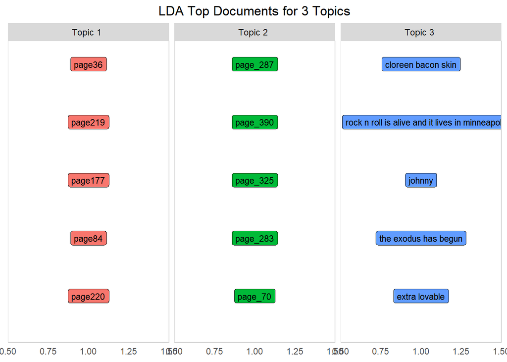

```r
number_of_documents=5 # number of top docs to view
title<- paste0("LDA Top Documents for",k,"Topics")

# Create tidy form showing topic, document and its gamma value
topics_tidy<-tidy(lda,matrix="gamma")

# same process as used with the top words
top_documents<-topics_tidy %>%
  group_by(topic) %>%
  arrange(topic,desc(gamma)) %>%
  slice(seq_len(number_of_documents)) %>%
  arrange(topic,gamma) %>%
  mutate(row=row_number()) %>%
  ungroup() %>%
  # re-label topics
  mutate(topic=paste("Topic",topic,seq=""))

title<-paste("LDA Top Documents for",k,"Topics")
word_chart(top_documents,top_documents$document,title)
```

## Identify Artists/Authors

Since you may not know the nomenclature of the document/song titles (i.e. pages with an underscore are from the machine learning book), I’ll replace the document name with the source name.

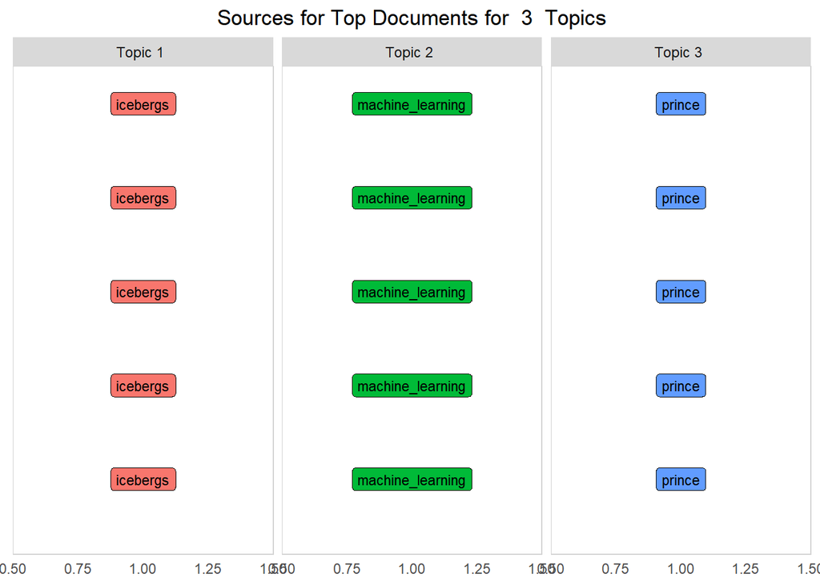

```r
title<-paste("Sources for Top Documents for ",k," Topics")

topics_tidy<-tidy(lda,matrix="gamma")

top_sources<-top_documents %>%
  #join back to the tidy form to get the source field
  inner_join(source_tidy) %>%
  select(document,source,topic) %>%
  distinct() %>%
  group_by(topic) %>%
  #needed by word_chart (not relevant here)
  mutate(row=row_number()) %>%
  ungroup()

word_chart(top_sources,top_sources$source,title)
```

The top documents for each topic as shown in the previous chart are replaced by their source. Your code has done well at classifying these documents because they fell into the same category (at least for these top 5)! The big question is whether or not this works with more than just three sources. If your results are accurate, you can then recommend writers with similar topics.

# Model Two : K-means for three writers

you will cretae your second model using a different machine learning technique : the k-means algorithm. As with LDA, k-means is an unsupevised learning algorithm and requires you to decide the number of topics ahead of time. In contrast to the LDA mixed-membership mode, k-means partitions the documents into apparent disjoint clusters(i.e. topics). Here, the algorithm clusters documents into different groups based on a similarity measure. It transforms documents to a numeric vector with weights assigned to words per document(similar to tf-idf.) Each document will show up in exactly one cluster. This is called hard clustering. The output is a set of clusters along with their documents. In contrast, LDA is a fuzzy (soft) clustering technique where a data point can belong to more than one cluster.

So conceptually, when applied to natural language, LDA should give more realistic results than k-means for topic assignment, given that text usually entails more than one topic. Build your model now, examine the k-means object, and see if your assumption holds true.

## Set Variables and Fit the Model

```r
# use the same three sources you started with
source_dtm<-three_sources_dtm_balanced
source_tidy<-three_sources_tidy_balanced

# SEt a seed for replicable results
set.seed(1234)
k<-3
kmeansResult<-kmeans(source_dtm,k)
str(kmeansResult)
```

```
## List of 9
##  $ cluster     : Named int [1:1449] 1 3 2 2 3 1 3 2 2 3 ...
##   ..- attr(*, "names")= chr [1:1449] "push it up" "shake" "party up" "style" ...
##  $ centers     : num [1:3, 1:13608] 42 0.01065 0.00758 0 0.01141 ...
##   ..- attr(*, "dimnames")=List of 2
##   .. ..$ : chr [1:3] "1" "2" "3"
##   .. ..$ : chr [1:13608] "push" "shake" "party" "style" ...
##  $ totss       : num 237535
##  $ withinss    : num [1:3] 640 202211 28285
##  $ tot.withinss: num 231137
##  $ betweenss   : num 6398
##  $ size        : int [1:3] 2 1315 132
##  $ iter        : int 3
##  $ ifault      : int 0
##  - attr(*, "class")= chr "kmeans"
```

```r
head(kmeansResult$cluster["page106"]) # classification for doc
```

```
## page106
##       2
```

```r
head(kmeansResult$centers[,"minor"]) # classify probabilities for words
```

```
##           1           2           3
## 0.000000000 0.002281369 0.000000000
```

## Identify K-means Themes with top words

Remember that this dataset contains three sources: Prince, Icebergs, and Machine Learning. Print the top words for each cluster and compare your results to the LDA output. You’ll need to manipulate the format of the data just a bit in order to use your word_chart() function. You can follow along with the code, but the details are not as important here as the actual analysis of the top words.

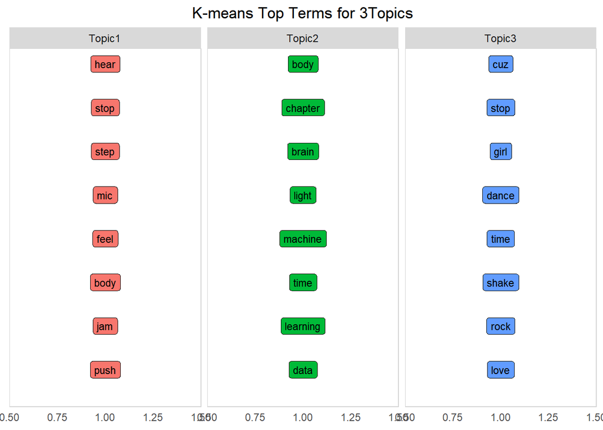

```r
num_words<-8 # number of words to display
#get the top words from the kmeans centers
kmeans_topics<-lapply(1:k,function(i){
  s<-sort(kmeansResult$centers[i,],decreasing = T)
  names(s)[1:num_words]
})

#make sure it's a data frame
kmeans_topics_df<-as.data.frame(kmeans_topics)
#label the topics with the word Topic
names(kmeans_topics_df)<-paste0("Topic",seq(1:k))
#create a sequential row id to use with gather()
kmeans_topics_df<-cbind(id=rownames(kmeans_topics_df),
                        kmeans_topics_df)

#transpose it into the format required for word_chart()
kmeans_top_terms<-kmeans_topics_df %>% gather(id,1:k)
colnames(kmeans_top_terms)=c("topic","term")

kmeans_top_terms<-kmeans_top_terms %>%
  group_by(topic) %>%
  mutate(row=row_number()) %>%  # need by word_chart()
  ungroup()

title<-paste0("K-means Top Terms for ",k ,"Topics")
word_chart(kmeans_top_terms,kmeans_top_terms$term,title)
```

The k-means algorithm is smart enough to separate topics between books and music. In other words, Topic1 and 3 are clearly Prince themes, and Topic2 is a combination of the two books. However, it was not able to distinguish between the two books themselves as you were able to do using LDA. K-means can be tuned for better performance, but so can LDA. At a quick glancem with default parameters, k-means does not seem to perform as well as LDA, and in fact, hard clustering is typically not used as much for topic modeling (For another option, chec out the mallet package).

### https://www.datacamp.com/community/tutorials/ML-NLP-lyric-analysis